# Plotting PCA/clustering results using ggplot2 and ggfortify

This document explains PCA/clustering related plotting using `ggplot2` and `ggfortify`.

# Installation

First, install `ggfortify` from [github](https://github.com/sinhrks/ggfortify).

```r
library(devtools)
install_github('sinhrks/ggfortify')
```

# Plotting PCA (Principal Component Analysis)

`ggfortify` let `ggplot2` know how to interpret PCA objects. After loading `ggfortify`, you can use `ggplot2::autoplot` function for `stats::prcomp` and `stats::princomp` objects.

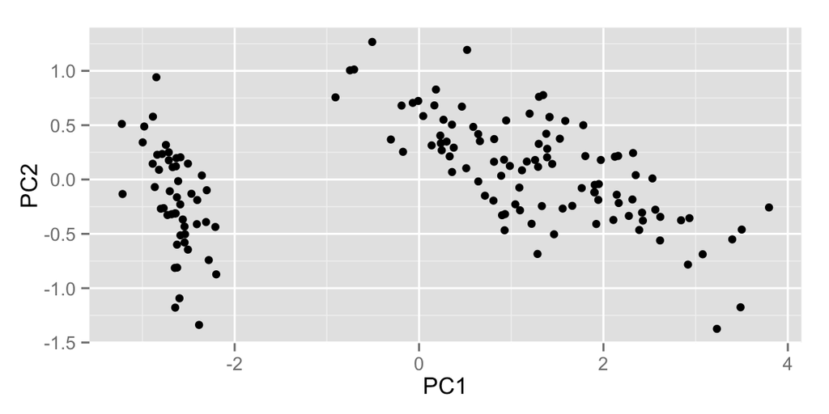

```r
library(ggplot2)
library(ggfortify)
df <- iris[c(1, 2, 3, 4)]
autoplot(prcomp(df))
```

PCA result should only contains numeric values. If you want to colorize by non-numeric values which original data has, pass original data using `original` keyword and then specify column name by `colour` keyword. Use `help(autoplot.prcomp)` (or `help(autoplot.*)` for any other objects) to check available options.

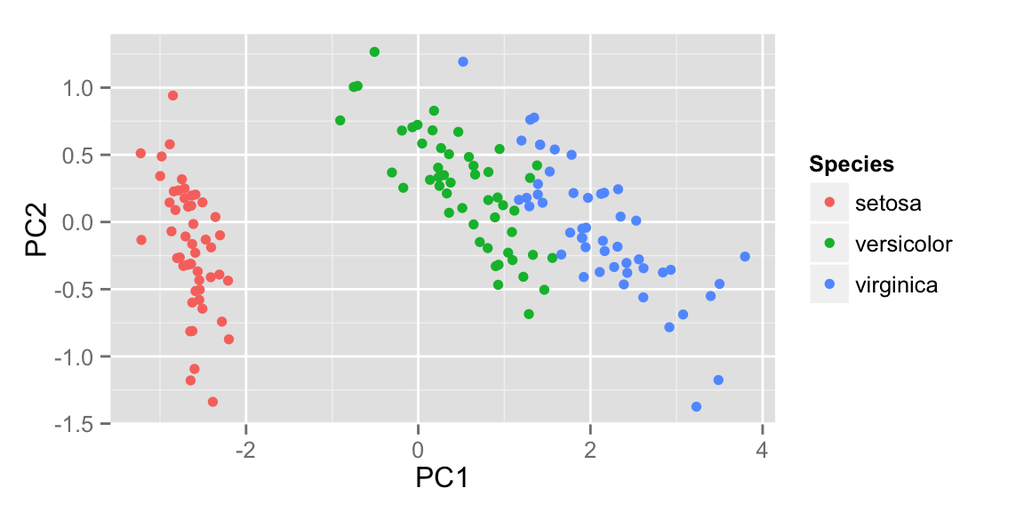

```r
autoplot(prcomp(df), original = iris, colour = 'Species')
```

Passing `label = TRUE` draws each data label using `rownames`

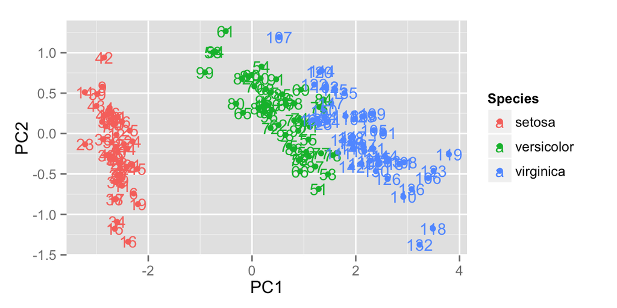

```r
autoplot(prcomp(df), original = iris, colour = 'Species', label = TRUE)
```

Passing `loadings = TRUE` draws eigenvectors.

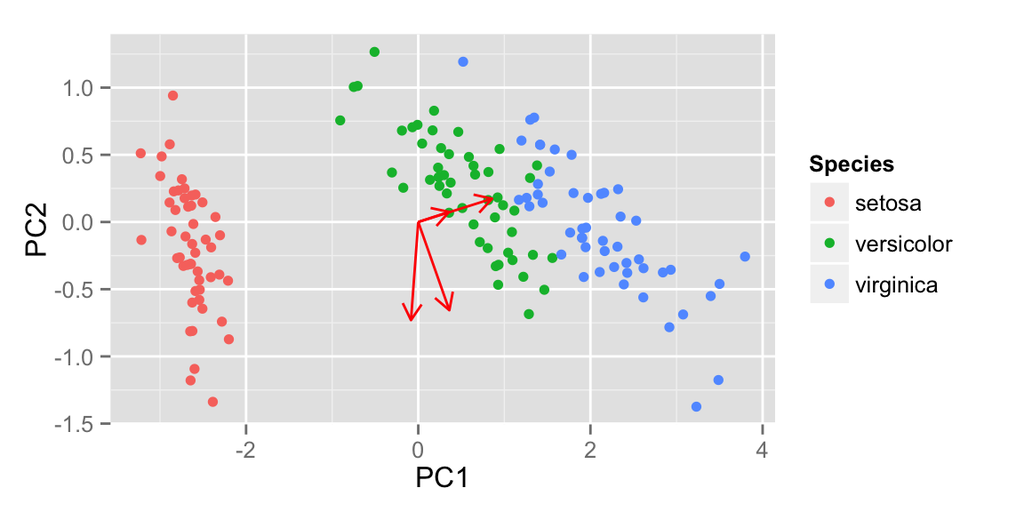

```r
autoplot(prcomp(df), original = iris, colour = 'Species', loadings = TRUE)
```

You can attach eigenvector labels and change some options.

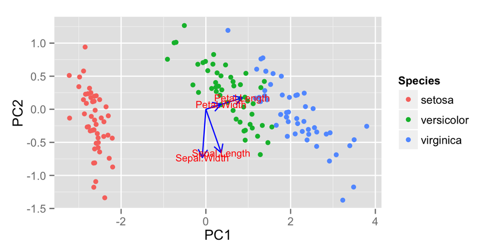

```r
autoplot(prcomp(df), original = iris, colour = 'Species',
         loadings = TRUE, loadings.colour = 'blue',
         loadings.label = TRUE, loadings.label.size = 3)
```

# Plotting Factor Analysis

`ggfortify` supports `stats::factanal` object as the same manner as PCAs. Available opitons are the same as PCAs.

**Important** You must specify `scores` option when calling `factanal` to calcurate sores (default `scores = NULL`). Otherwise, plotting will fail.

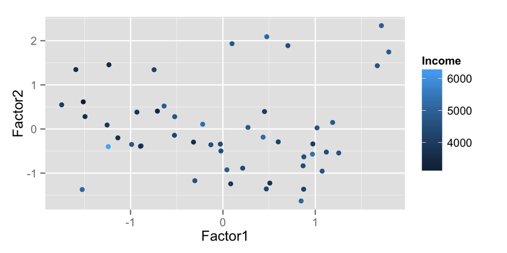

```r
d.factanal <- factanal(state.x77, factors = 3, scores = 'regression')
autoplot(d.factanal, original = state.x77, colour = 'Income')
```

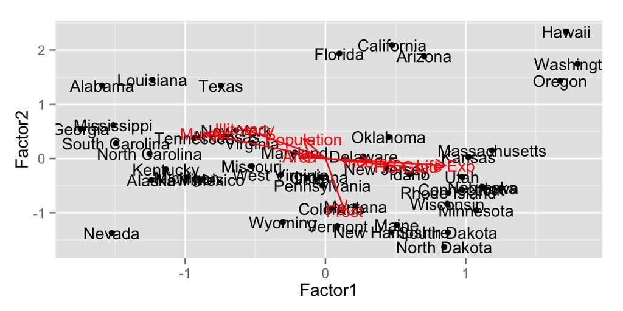

```r
autoplot(d.factanal, label = TRUE, loadings = TRUE, loadings.label = TRUE)
```

# Plotting K-means

`ggfortify` supports `stats::kmeans` class. You must explicitly pass original data to `autoplot` function via `original` keyword. Because `kmeans` object doesn’t store original data. The result will be automatically colorized by categorized cluster.

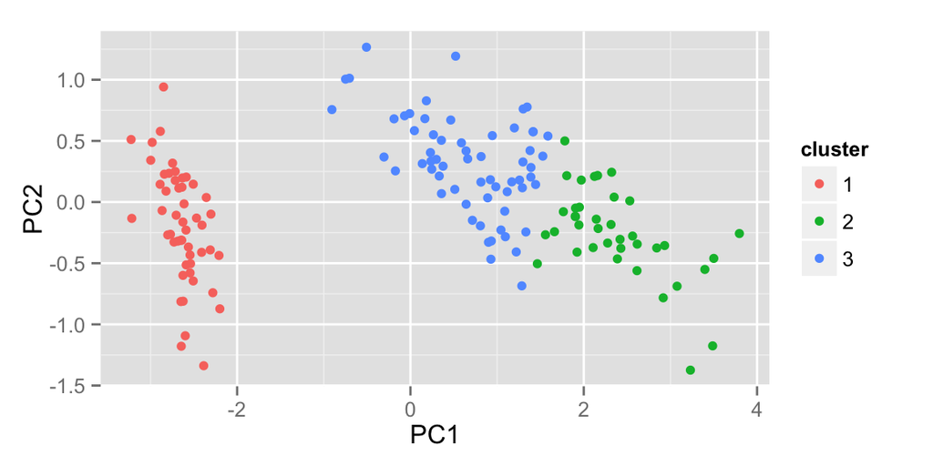

```r
set.seed(1)
df <- iris[-5]
autoplot(kmeans(df, 3), original = iris)
```

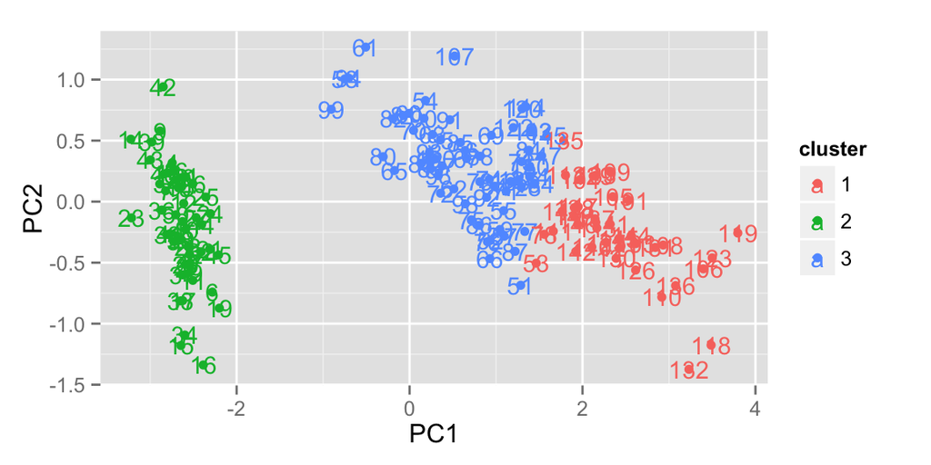

```r
autoplot(kmeans(df, 3), original = iris, label = TRUE)
```

# Plotting cluster package

`ggfortify` supports `cluster::clara`, `cluster::fanny`, `cluster::pam` classes. Because these instances should contains original data in its property, there is no need to pass original data explicitly.

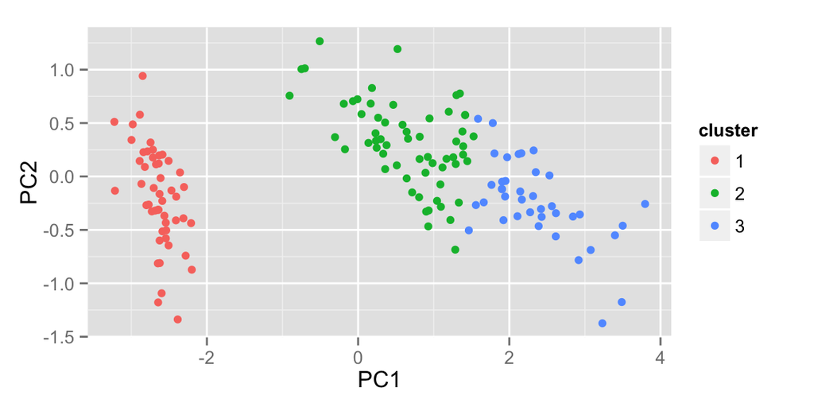

```r
library(cluster)
autoplot(clara(df, 3))
```

Specifying `frame = TRUE` in `autoplot` for `stats::kmeans` and `cluster::*` draws convex for each cluster.

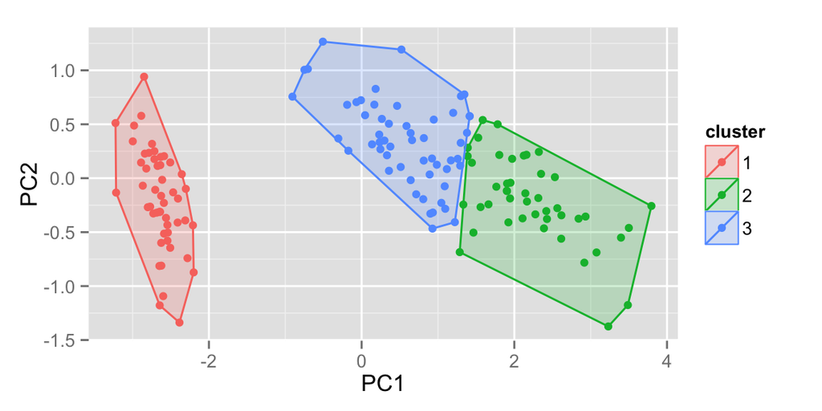

```r
autoplot(fanny(df, 3), frame = TRUE)
```

If you want probability ellipse, `ggplot2` 1.0.0 or later is required. Specify whatever supported in [`ggplot2::stat_ellipse`](http://docs.ggplot2.org/dev/stat_ellipse.html)’s `type` keyword via `frame.type` option.

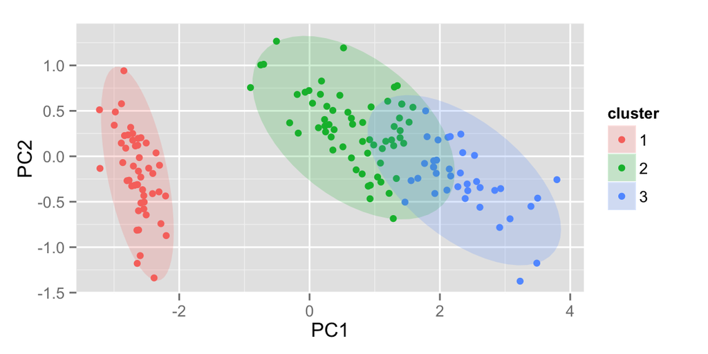

```r
autoplot(pam(df, 3), frame = TRUE, frame.type = 'norm')
```

# Resources related to ggfortify

- [Plotting Diagnostics for LM and GLM with ggplot2 and ggfortify](http://rpubs.com/sinhrks/plot_lm)
- [Plotting Time Series with ggplot2 and ggfortify](http://rpubs.com/sinhrks/plot_ts)
- [Plotting Time Series Statistics with ggplot2 and ggfortify](http://rpubs.com/sinhrks/plot_tsstats)
- [Plotting PCA/clustering results using ggplot2 and ggfortify](http://rpubs.com/sinhrks/plot_pca)
- [Plotting Multidimensional Scaling using ggplot2 and ggfortify](http://rpubs.com/sinhrks/plot_mds)
- [Plotting Survival Curves using ggplot2 and ggfortify](http://rpubs.com/sinhrks/plot_surv)
- [Plotting Probability Distributions with ggplot2 and ggfortify](http://rpubs.com/sinhrks/plot_dist)